# Time Series CV

Tiago Souza

1/31/2022

## Step 0: Parameters

```r
# Number of periods to forecast
forecast_length <- 20
# Number of periods in test sample
test_size <- 24
# Initial number of periods included in a split
initial_periods <- 36
# Lags
lag_vec <- c(1,12)
lag_max <- max(lag_vec)
# Number of splits in output
splits_number <- 10
```

## Step 1: Download and tidy data

In this example we will use Manufacturing production data from Brazil.

Notice below that codes appear as variable names, the first row of the data frame contains information about the variables (not data itself), and all variables are character.

```r
data_links <- list(
  manufacturing = "https://apisidra.ibge.gov.br/values/t/3653/v/3134/c544/129316/p/all/n1/all",
  retail = "https://apisidra.ibge.gov.br/values/t/3417/v/1186/c11046/40312/p/all/n1/all")

download_data <- function(url) {
  data <- GET(url = url) %>%
    content(as = "parsed") %>%
    map_dfr(., ~.)
}

data <- map_dfr(data_links, download_data, .id = "variable") %>%

  filter(NC == "1") %>%

  transmute(
    variable = variable,
    date = ymd(paste0(D3C,"01")),
    value = as.numeric(V)) %>%

  group_by(variable) %>%

  mutate(value = value / lag(value, n=1) - 1) %>%

  drop_na() %>%

  ungroup()

print(data)
```

```
## # A tibble: 466 × 3
##    variable      date          value
##    <chr>         <date>        <dbl>
##  1 manufacturing 2002-02-01  0.0306
##  2 manufacturing 2002-03-01 -0.00990
##  3 manufacturing 2002-04-01  0.00500
##  4 manufacturing 2002-05-01 -0.00373
##  5 manufacturing 2002-06-01  0.00125
##  6 manufacturing 2002-07-01  0.00748
##  7 manufacturing 2002-08-01 -0.00743
##  8 manufacturing 2002-09-01  0.00499
##  9 manufacturing 2002-10-01  0.00248
## 10 manufacturing 2002-11-01 -0.00248
## # … with 456 more rows
```

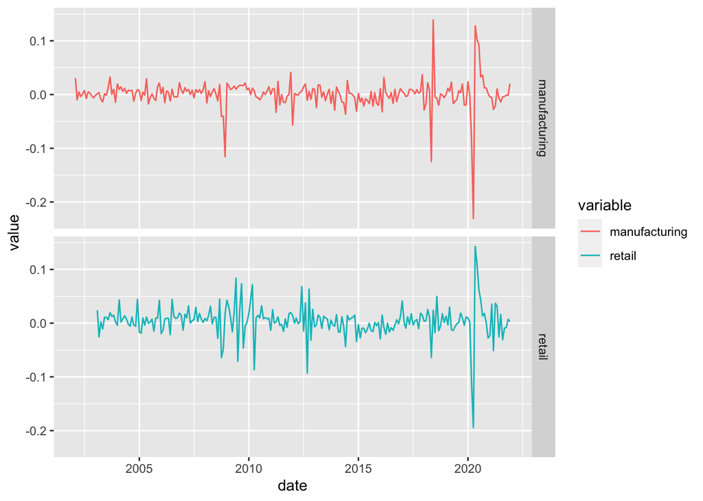

```r
data %>%
  ggplot(aes(x = date, y = value, color = variable)) +
  geom_line() +
  facet_grid(variable ~ .)
```

## Step 2: Define models

Here we define a set of models and the names of their respective recipes. What defines one specification is a pair model-recipe.

```r
source("basic_workflows.R")

models_def <- tribble(
  ~model_id, ~recipe_id,
  "lm", "recipe_primary",
  "xgb", "recipe_primary",
  "rf", "recipe_primary",
  "svm", "recipe_primary",
  "lm", "recipe_lag",
  "xgb", "recipe_lag",
  "rf", "recipe_lag",
  "svm", "recipe_lag"
) %>%

  mutate(workflow = map(model_id, ~get(.x)))

head(models_def)
```

```
## # A tibble: 6 × 3
##   model_id recipe_id      workflow
##   <chr>    <chr>          <list>
## 1 lm       recipe_primary <workflow>
## 2 xgb      recipe_primary <workflow>
## 3 rf       recipe_primary <workflow>
## 4 svm      recipe_primary <workflow>
## 5 lm       recipe_lag     <workflow>
## 6 xgb      recipe_lag     <workflow>
```

## Step 3: Split Data - train/test

```r
data_complete <- data %>%

  group_nest(variable) %>%

  mutate(
    data_split = map(data, ~ .x %>% time_series_split(
                                      date_var = date,
                                      initial = initial_periods,
                                      assess = test_size,
                                      lag = lag_max,
                                      cumulative = TRUE,
                                      slice = 1)),
    data_train = map(data_split, ~ .x %>% training()),
    data_test = map(data_split, ~ .x %>% testing()),
    data_extended = map(data, ~ .x %>% future_frame(
                                        .date_var = date,
                                        .length_out = forecast_length,
                                        .bind_data = TRUE)),
    data_forecast = map(data_extended, ~ .x %>% filter(is.na(value)))
    ) %>%

  select(-data_split)

print(data_complete)
```

```
## # A tibble: 2 × 6
##   variable                 data data_train data_test data_extended data_forecast
##   <chr>         <list<tibble[,> <list>     <list>    <list>        <list>
## 1 manufacturing       [239 × 2] <tibble>   <tibble>  <tibble>      <tibble>
## 2 retail              [227 × 2] <tibble>   <tibble>  <tibble>      <tibble>
```

## Step 4: Split Data - CV

Remember that a recipe is defined by an equation and a data set. Hence, before creating recipes, we must split the training data.

```r
data_splits <- data_complete %>%

  transmute(
    variable = variable,
    split = map(data_train, ~ .x %>% time_series_cv(
                                      date_var = date,
                                      initial = initial_periods,
                                      assess = forecast_length,
                                      lag = lag_max,
                                      cumulative = TRUE,
                                      slice_limit = splits_number))) %>%

  unnest(split) %>%

  rename(split_id = id,
         split = splits)

head(data_splits)
```

```
## # A tibble: 6 × 3
##   variable      split            split_id
##   <chr>         <list>           <chr>
## 1 manufacturing <split [195/32]> Slice01
## 2 manufacturing <split [194/32]> Slice02
## 3 manufacturing <split [193/32]> Slice03
## 4 manufacturing <split [192/32]> Slice04
## 5 manufacturing <split [191/32]> Slice05
## 6 manufacturing <split [190/32]> Slice06
```

## Step 5: Recipes

We create 2 examples of recipes, based on a fixed column name with data (“value”) and a fixed specification of lag structure (lag 1 and 12). Notice that the column “date” must be removed from the data in order to run.

```r
create_recipe <- function(data, recipe_id) {

  data <- tryCatch(training(data),
                   error = function(e) data)

  recipe_primary <- recipe(value ~ ., data = data) %>%
                      step_mutate(month = as_factor(month(date))) %>%
                      step_dummy(month, one_hot = FALSE) %>%
                      step_rm(date)

  recipe_lag <- recipe(value ~ ., data = data) %>%
                      step_mutate(month = as_factor(month(date))) %>%
                      step_dummy(month, one_hot = FALSE) %>%
                      step_lag(value, lag = lag_vec) %>%
                      step_naomit(all_predictors()) %>%
                      step_rm(date)

  return(get(recipe_id))

}
```

## Step 5: Complete tibble with all components

```r
models_components <- models_def %>%

  expand_grid(data_splits) %>%

  mutate(
    recipe = map2(split, recipe_id, ~ create_recipe(.x, .y)),
    workflow = map2(workflow, recipe, ~ .x %>% add_recipe(.y))
    ) %>%

  select(-recipe)

head(models_components)
```

```
## # A tibble: 6 × 6
##   model_id recipe_id      workflow   variable      split            split_id
##   <chr>    <chr>          <list>     <chr>         <list>           <chr>
## 1 lm       recipe_primary <workflow> manufacturing <split [195/32]> Slice01
## 2 lm       recipe_primary <workflow> manufacturing <split [194/32]> Slice02
## 3 lm       recipe_primary <workflow> manufacturing <split [193/32]> Slice03
## 4 lm       recipe_primary <workflow> manufacturing <split [192/32]> Slice04
## 5 lm       recipe_primary <workflow> manufacturing <split [191/32]> Slice05
## 6 lm       recipe_primary <workflow> manufacturing <split [190/32]> Slice06
```

## Step 6: Fitting models to all splits

```r
models_fitted <- models_components %>%

  mutate(fit = map2(workflow, split, ~ fit(.x, data = training(.y)))) %>%

  select(-workflow)

head(models_fitted)
```

[output not shown]

## Step 7: Calibrated data for test sample

```r
data_calibr <- models_fitted %>%

  mutate(
    fitted_recipe = map(fit, ~ extract_recipe(.x)),
    fitted_model = map(fit, ~ extract_fit_parsnip(.x)),
    data = map(split, ~ testing(.x)),
    data_test = map2(fitted_recipe, data, ~ bake(.x, .y)),
    pred = map2(fitted_model, data_test, ~ predict(.x, new_data = .y %>% select(-value))),
    across(c(data, pred), ~ map(.x, function(x) slice_tail(x, n = forecast_length))),
    data = map2(data, pred, ~ .x %>% bind_cols(.y))
  ) %>%

  select(variable,
         model_id,
         recipe_id,
         split_id,
         data) %>%

  unnest(data)

head(data_calibr)
```

```
## # A tibble: 6 × 7
##   variable      model_id recipe_id      split_id date          value    .pred
##   <chr>         <chr>    <chr>          <chr>    <date>        <dbl>    <dbl>
## 1 manufacturing lm       recipe_primary Slice01  2016-05-01 -0.00237  0.00319
## 2 manufacturing lm       recipe_primary Slice01  2016-06-01 -0.00712 -0.00407
## 3 manufacturing lm       recipe_primary Slice01  2016-07-01  0.00358  0.00213
## 4 manufacturing lm       recipe_primary Slice01  2016-08-01 -0.0167   0.00235
## 5 manufacturing lm       recipe_primary Slice01  2016-09-01  0.00969  0.00313
## 6 manufacturing lm       recipe_primary Slice01  2016-10-01 -0.0132  -0.00366
```

## Step 8: Error metrics

```r
error_metrics <- data_calibr %>%

  group_by(variable, model_id, recipe_id, split_id) %>%

  metrics(value, .pred) %>%

  group_by(variable, model_id, recipe_id, .metric) %>%

  summarize(mean_error = mean(.estimate), .groups = "drop_last")

head(error_metrics)
```

```
## # A tibble: 6 × 5
## # Groups:   variable, model_id, recipe_id [2]
##   variable      model_id recipe_id      .metric mean_error
##   <chr>         <chr>    <chr>          <chr>        <dbl>
## 1 manufacturing lm       recipe_lag     mae        0.00885
## 2 manufacturing lm       recipe_lag     rmse       0.0124
## 3 manufacturing lm       recipe_lag     rsq        0.0448
## 4 manufacturing lm       recipe_primary mae        0.00897
## 5 manufacturing lm       recipe_primary rmse       0.0125
## 6 manufacturing lm       recipe_primary rsq        0.0318
```

## Step 9: Best model

The metric of choice will be “MAE”.

```r
best_model <- error_metrics %>%

  filter(.metric == "mae") %>%

  group_by(variable) %>%

  filter(mean_error == min(mean_error)) %>%

  select(variable, model_id, recipe_id)

head(best_model)
```

```
## # A tibble: 2 × 3
## # Groups:   variable [2]
##   variable      model_id recipe_id
##   <chr>         <chr>    <chr>
## 1 manufacturing lm       recipe_lag
## 2 retail        rf       recipe_primary
```

## Step 10: Refit best models

```r
refit_models <- best_model %>%

  left_join(data_complete, by = "variable") %>%

  left_join(models_def, by = c("model_id", "recipe_id")) %>%

  mutate(
    recipe = map2(data_train, recipe_id, ~ create_recipe(.x, .y)),
    workflow = map2(workflow, recipe, ~ .x %>% add_recipe(.y)),
    fit = map2(workflow, data_train, ~ fit(.x, data = .y)),
    fitted_recipe = map(fit, ~ extract_recipe(.x)),
    fitted_model = map(fit, ~ extract_fit_parsnip(.x))
  ) %>%

  ungroup()

head(refit_models)
```

```
## # A tibble: 2 × 13
##   variable      model_id recipe_id       data data_train data_test data_extended
##   <chr>         <chr>    <chr>      <list<ti> <list>     <list>    <list>
## 1 manufacturing lm       recipe_lag [239 × 2] <tibble>   <tibble>  <tibble>
## 2 retail        rf       recipe_pr… [227 × 2] <tibble>   <tibble>  <tibble>
## # … with 6 more variables: data_forecast <list>, workflow <list>,
## #   recipe <list>, fit <list>, fitted_recipe <list>, fitted_model <list>
```

## Step 11: Performance with respect to test data

```r
data_perf <- refit_models %>%

  select(variable,
         data_test,
         fitted_recipe,
         fitted_model) %>%

  mutate(
    data_test = map2(fitted_recipe, data_test, ~ bake(.x, .y)),
    pred = map2(fitted_model, data_test, ~ predict(.x, new_data = .y %>% select(-value))),
    across(c(data_test, pred), ~ map(.x, function(x) slice_tail(x, n = forecast_length))),
    data_test = map2(data_test, pred, ~ .x %>% select(value) %>%  bind_cols(.y))
  ) %>%

  select(
    variable,
    data_test
  ) %>%

  unnest(data_test)

head(data_perf)
```

```
## # A tibble: 6 × 3
##   variable       value    .pred
##   <chr>          <dbl>    <dbl>
## 1 manufacturing 0.128   0.0466
## 2 manufacturing 0.102  -0.0241
## 3 manufacturing 0.0937 -0.0197
## 4 manufacturing 0.0326 -0.0193
## 5 manufacturing 0.0362 -0.00451
## 6 manufacturing 0.0124 -0.0114
```

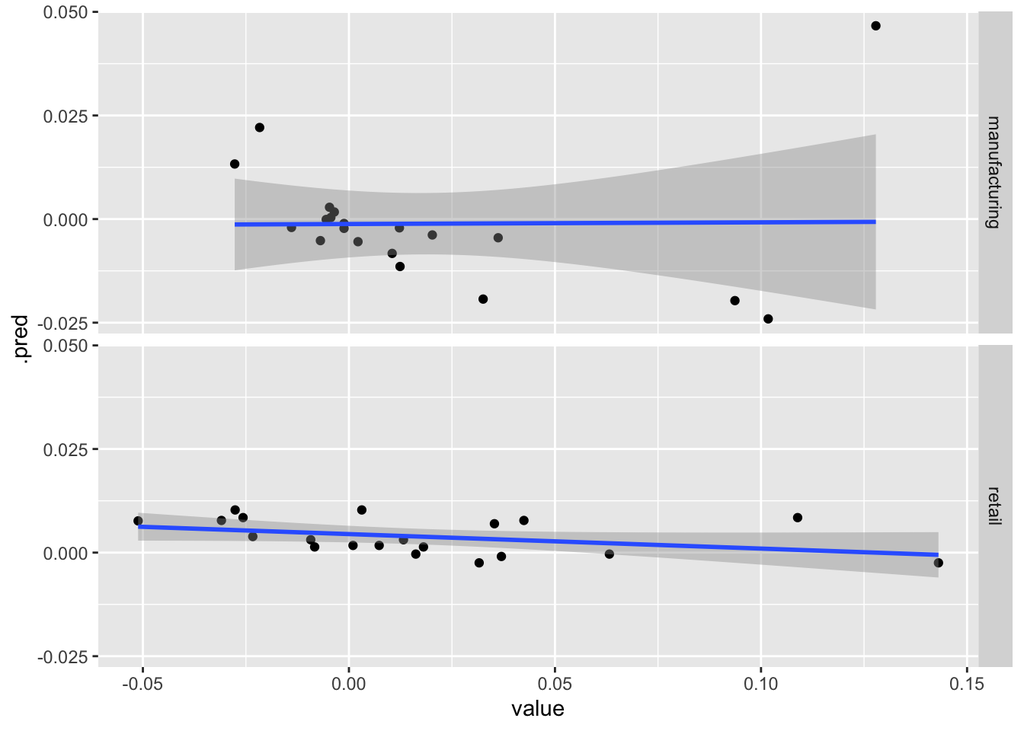

```r
data_perf %>%

  ggplot(aes(x=value, y=.pred))+
    geom_point()+
    geom_smooth(method = "lm", formula = y ~ x)+
    facet_grid(variable ~ .)
```

## Step 11: Forecasts

Now we turn to forecasting the future, and for that we will need a recursive approach. This is needed since to forecast $n$ periods ahead, given the existence of lag variables in the models, it is needed to have the forecast for the $n-1$ previous periods.

```r
check_forecast <- function(df_refit) {

  check <- df_refit %>%

  select(data_forecast) %>%

  transmute(check = map(data_forecast, ~ .x %>%
                       select(value) %>%
                       anyNA()),
            check = as.logical(check)) %>%

  use_series(check) %>%

  any()

  return(check)

}

final <- refit_models

while(check_forecast(final)) {

final <- final %>%

  mutate(
    pred = map2(fitted_recipe, data_extended, ~ bake(.x, .y) %>% slice_tail(n = 1)),
    pred = map(pred, ~ .x %>% filter(is.na(value)) %>% select(-value)),
    pred = map2(fitted_model, pred, ~ predict(.x, new_data = .y)),
    pred = map2(data_forecast, pred,
                ~ .x %>% filter(is.na(value)) %>%
                  mutate(value = if_else(date == min(date),
                                         .y %>% use_series(.pred),
                                         value))),
    data_forecast = map2(data_forecast, pred, ~ .x %>% rows_update(.y, by = "date")),
    data_extended = map2(data_extended, pred, ~ .x %>% rows_update(.y, by = "date"))
    )
}

final <- final %>%
  select(variable,
         data,
         data_forecast)

head(final)
```

```
## # A tibble: 2 × 3
##   variable                    data data_forecast
##   <chr>         <list<tibble[,2]>> <list>
## 1 manufacturing          [239 × 2] <tibble [20 × 2]>
## 2 retail                 [227 × 2] <tibble [20 × 2]>
```

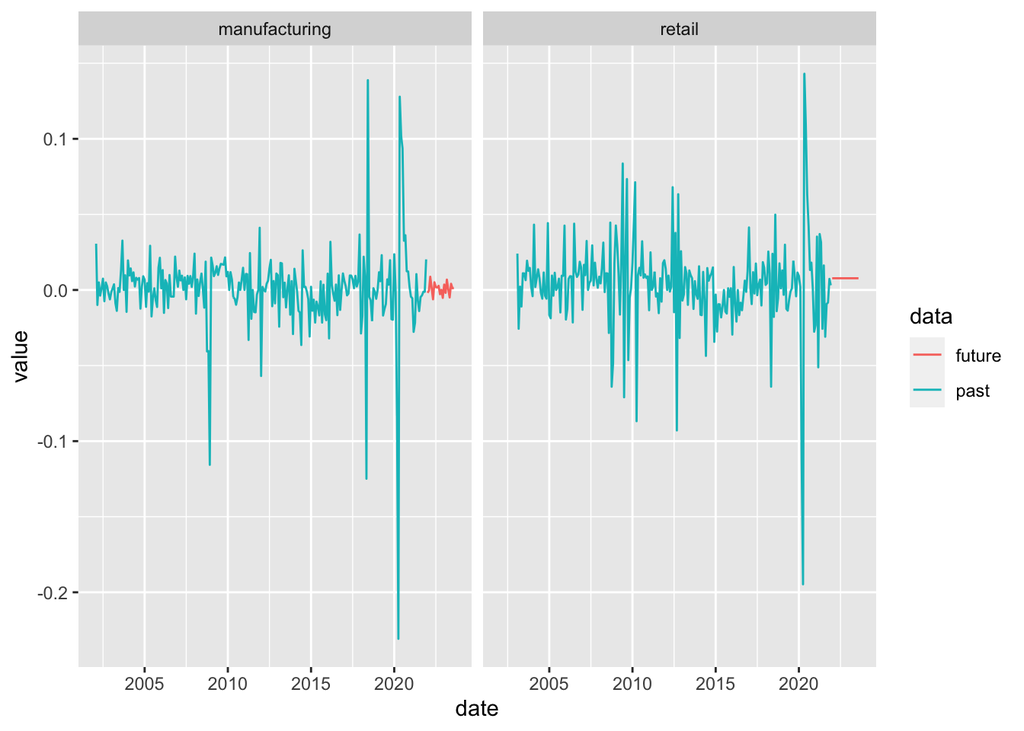

```r
plot_final <- final %>%

  select(-data_forecast) %>%

  unnest(data) %>%

  mutate(data = "past") %>%

  bind_rows(final %>%
              select(-data) %>%
              unnest(data_forecast) %>%
              mutate(data = "future"))

plot_final %>%

  ggplot(aes(x = date, y = value, color = data)) +
    geom_line() +
    facet_grid(. ~ variable)
```